# Corine land cover analysis of Europe

RS-eco

2022-03-15

```r
library(dplyr); library(sf); library(ggplot2)
library(tidyr); library(scico)
```

```r
# Load shapefile of Europe
data("europe", package="edc")
```

# General information

The land cover data originates from: https://land.copernicus.eu/pan-european/corine-land-cover There you can also find additional information on the data.

The data is based on satellite images and there is data for 5 different years (1990, 2000, 2006, 2012, 2018). The data originally has a resolution of 100 x 100 m. In this resolution there is one land cover class per grid cell.

The European data was aggregated to a coarser resolution and contain for each land-cover class the percentage cover per grid cell.

Overall, the dataset discriminates between 45 different land-cover classes:

Continuous urban fabric, Discontinuous urban fabric, Industrial or commercial units, Road and rail networks and associated land, Port areas, Airports, Mineral extraction sites, Dump sites, Construction sites, Green urban areas, Sport and leisure facilities, Non-irrigated arable land, Permanently irrigated land, Rice fields, Vineyards, Fruit trees and berry plantations, Olive groves, Pastures, Annual crops associated with permanent crops, Complex cultivation patterns, Land principally occupied by agriculture with significant areas of natural vegetation, Agro-forestry areas, Broad-leaved forest, Coniferous forest, Mixed forest, Natural grasslands, Moors and heathland, Sclerophyllous vegetation, Transitional woodland-shrub, Beaches dunes sands, Bare rocks, Sparsely vegetated areas, Burnt areas, Glaciers and perpetual snow, Inland marshes, Peat bogs, Salt marshes, Salines, Intertidal flats, Water courses, Water bodies, Coastal lagoons, Estuaries, Sea and ocean, NODATA

## Colour key of Corine land-cover classes

Each land-cover class is associated with a certain colour, which are provided here:

```r
# Named vector of clc colours
clc_cols <- c("Continuous urban fabric" = "#e6004d", "Discontinuous urban fabric" = "#ff0000", "Industrial or commercial units" = "#cc4df2", "Road and rail networks and associated land" = "#cc0000", "Port areas" = "#e6cccc", "Airports" = "#e6cce6", "Mineral extraction sites" = "#a600cc", "Dump sites" = "#a64d00", "Construction sites" = "#ff4dff", "Green urban areas" = "#ffa6ff", "Sport and leisure facilities" = "#ffe6ff", "Non-irrigated arable land" = "#ffffa8", "Permanently irrigated land" = "#ffff00", "Rice fields" = "#e6e600", "Vineyards" = "#e68000", "Fruit trees and berry plantations" = "#f2a64d", "Olive groves" = "#e6a600", "Pastures" = "#e6e64d", "Annual crops associated with permanent crops" = "#ffe6a6", "Complex cultivation patterns" = "#ffe64d", "Land principally occupied by agriculture with \n significant areas of natural vegetation" = "#e6cc4d", "Agro-forestry areas" = "#f2cca6", "Broad-leaved forest" = "#80ff00", "Coniferous forest" = "#00a600", "Mixed forest" = "#4dff00", "Natural grasslands" = "#ccf24d", "Moors and heathland" = "#a6ff80", "Sclerophyllous vegetation" = "#a6e64d", "Transitional woodland-shrub" = "#a6f200", "Beaches - dunes - sands" = "#e6e6e6", "Bare rocks" = "#cccccc", "Sparsely vegetated areas" = "#ccffcc", "Burnt areas" = "#000000", "Glaciers and perpetual snow" = "#a6e6cc", "Inland marshes" = "#a6a6ff", "Peat bogs" = "#4d4dff", "Salt marshes" = "#ccccff", "Salines" = "#e6e6ff", "Intertidal flats" = "#a6a6e6", "Water courses" = "#00ccf2", "Water bodies" = "#80f2e6", "Coastal lagoons" = "#00ffa6", "Estuaries" = "#a6ffe6", "Sea and ocean" = "#e6f2ff", "NODATA" = "#ffffff")
```

# Data Analysis

Here, I perform a first analysis of the Corine Land-Cover and Land-Cover Change Data for Europe.

## Corine land-cover of Europe

### Map of % cover of certain land-cover classes

[figure not shown]

```r
#data("corine_lc_eur_p11deg", package="edc")
data("corine_lc_eur_p44deg", package="edc")

# Plot data from long format
#corine_lc_eur_p11deg %>%
#  filter(var %in% c("Pastures", "Broad-leaved forest", "Coniferous forest",
#                    "Mixed forest", "Natural grasslands")) %>%
#  pivot_longer(names_to="year", values_to="value", -c(x,y,var)) %>%
#  ggplot() + geom_tile(aes(x=x, y=y, fill=value)) +
#  facet_grid(year~var) + scale_fill_scico(name="% Cover", palette="roma") +
#  geom_sf(data=europe, fill=NA) + coord_sf() + theme_bw() +
#  theme(strip.background = element_blank(), axis.title = element_blank())
#rm(corine_lc_eur_p11deg); invisible(gc())

# Plot data from long format
corine_lc_eur_p44deg %>%
  filter(var %in% c("Pastures", "Broad-leaved forest", "Coniferous forest",
                    "Mixed forest", "Natural grasslands")) %>%
  pivot_longer(names_to="year", values_to="value", -c(x,y,var)) %>%
  ggplot() + geom_tile(aes(x=x, y=y, fill=value)) +
  facet_grid(year~var) + scale_fill_scico(name="% Cover", palette="roma") +
  geom_sf(data=europe, fill=NA) + coord_sf() + theme_bw() +
  theme(strip.background = element_blank(), axis.title = element_blank())
```

### Forest map

```r
lc_eur <- corine_lc_eur_p44deg %>% dplyr::select(-c(`1990`, `2000`, `2006`,`2012`)) %>%
  pivot_wider(names_from="var", values_from=`2018`) %>%
  mutate_all(list(~replace_na(., 0)))
head(lc_eur)
```

```
#> # A tibble: 6 × 48
#>       x     y `Land principally…` `Broad-leaved …` `Moors and hea…` `Bare rocks`
#>   <dbl> <dbl>               <dbl>            <dbl>            <dbl>        <dbl>
#> 1  22.8  70.7             0.00237             1.18             7.68         5.33
#> 2  23.3  70.7             0.0700              1.83             8.32         7.23
#> 3  23.7  70.7             0.0348              1.49             6.00         3.56
#> 4  25.0  70.7             0.373               6.60            10.6          7.73
#> 5  25.5  70.7             0.227               3.42            13.8          3.91
#> 6  26.4  70.7             0.00101             4.88            11.1          9.24
#> # … with 42 more variables: `Sparsely vegetated areas` <dbl>,
#> #   `Glaciers and perpetual snow` <dbl>, `Peat bogs` <dbl>,
#> #   `Intertidal flats` <dbl>, `Water bodies` <dbl>, `Sea and ocean` <dbl>,
#> #   `NA` <dbl>, `Discontinuous urban fabric` <dbl>, Airports <dbl>,
#> #   `Sport and leisure facilities` <dbl>, `Water courses` <dbl>,
#> #   `Non-irrigated arable land` <dbl>, `Complex cultivation patterns` <dbl>,
#> #   `Mixed forest` <dbl>, `Beaches dunes sands` <dbl>, …
```

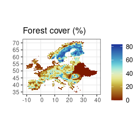

```r
lc_eur$forest <- lc_eur$`Agro-forestry areas` + lc_eur$`Coniferous forest` +
  lc_eur$`Mixed forest` + lc_eur$`Broad-leaved forest`

# Plot individual land-cover percentage cover
lc_eur %>% ggplot() + geom_tile(aes(x=x, y=y, fill=forest)) +
  scale_fill_scico(name="", palette="roma") +
  coord_sf() + theme_bw() + labs(x="", y="") +
  ggtitle("Forest cover (%)") +
  theme(legend.text = element_text(size=10))
```

```r
rm(lc_eur); invisible(gc())
```

### Map of dominant land-cover type

[figure not shown]

```r
# Calculate dominant land-cover class
dominant_clc <- corine_lc_eur_p44deg %>% group_by(x,y) %>% slice(which.max(`2018`)) %>%
  dplyr::select(x,y,var, `2018`) %>% mutate(var = as.factor(var)) %>% drop_na()

# Select available land-cover classes
clc_cols_eur <- clc_cols[names(clc_cols) %in% dominant_clc$var]
dominant_clc %>% ggplot() +
  geom_tile(aes(x=x, y=y, fill=var)) +
  scale_fill_manual(name="CLC2018", values=clc_cols_eur) +
  coord_sf() + theme_bw() + theme(legend.position="bottom") +
  labs(x="", y="")
```

```r
rm(corine_lc_eur_p44deg, dominant_clc); invisible(gc())
```